# R Tutorial #2 – Econ 103

# Summary Stats and Graphics

## Load the Data

In this section we’ll work with data from the student survey. Since results for this semester haven’t been collected yet, we’ll start with data from a previous semester:

```r
#You should have data.table installed from the first R tutorial.
#  if not, run the following line of code before library:
#  install.packages("data.table")
library(data.table)
survey = fread("http://www.ditraglia.com/econ103/old_survey.csv")
```

## Adding Columns

Adding and subtracting columns from a `data.table` is done with the special assignment operator `:=`, which I read as “defined as”. There are other ways to assign and remove columns from a `data.table` or `data.frame`, but there are issues with this approach; if you’re interested, see [here](https://rawgit.com/wiki/Rdatatable/data.table/vignettes/datatable-reference-semantics.html), [here](http://stackoverflow.com/questions/7029944/when-should-i-use-the-operator-in-data-table) and [here](http://stackoverflow.com/questions/7033106/why-has-data-table-defined-rather-than-overloading) for more background on this issue.

Let’s add a column to `survey` that is the ratio of `height` to `handspan`:

```r
survey[ , height_handspan_ratio := height/handspan]
```

As always with `data.table`s, when we’re doing an operation specifying something about *columns*, we do so in the *second* argument (often referred to as simply `j`) within the square brackets `[]`. The *first* argument (similarly, `i`) tells R which *rows* we’re interested in; by leaving it blank, we’re telling R to operate on *all* rows.

## Removing Columns

Removing a column from a `data.table` shares basically the same syntax as adding a columns – the crux is the `:=` operator. We’ll exclude columns 7 through 10:

```r
survey[ , 7:10 := NULL]
```

*Note: in general, it is not recommended to refer to columns by number, since the order might change unexpectedly. It’s safer to refer to columns by their name.*

## Previewing Data

It’s always a good idea to take a look at your data after loading it.

The functions `head` and `tail`, introduced in R Tutorial #1, make this easy:

```r
head(survey)
```

```
##       sex credits eye.color handedness height handspan
## 1:   Male       5     Brown        1.0     67     20.0
## 2: Female       5     Brown        0.4     63     19.5
## 3: Female      NA     Brown        0.6     62     19.0
## 4: Female       5     Brown        0.6     65     19.5
## 5: Female       4     Brown        1.0     62     18.5
## 6: Female      NA     Brown        1.0     68     18.5
##    height_handspan_ratio
## 1:              3.350000
## 2:              3.230769
## 3:              3.263158
## 4:              3.333333
## 5:              3.351351
## 6:              3.675676
```

```r
tail(survey)
```

```
##       sex credits eye.color handedness height handspan
## 1:   Male       4     Hazel       1.00     73     21.0
## 2:   Male       5     Brown       0.56     66     20.0
## 3: Female       5     Brown       0.80     63     18.0
## 4: Female       6     Brown       0.80     64     21.0
## 5: Female       6     Brown       1.00     61     17.5
## 6:   Male       5     Brown       0.70     71     24.5
##    height_handspan_ratio
## 1:              3.476190
## 2:              3.300000
## 3:              3.500000
## 4:              3.047619
## 5:              3.485714
## 6:              2.897959
```

## Histograms: `hist`

The command for a histogram in R is `hist`. Its input has to be a *vector*, not a `data.table`. Conveniently, we can use this function in the `j` argument. For example, we can make a histogram of the column `handedness` as follows:

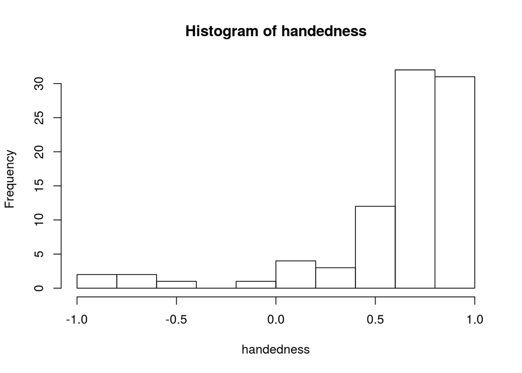

```r
survey[ , hist(handedness)]
```

The default title and axis labels aren’t very nice. We can change them using the following options:

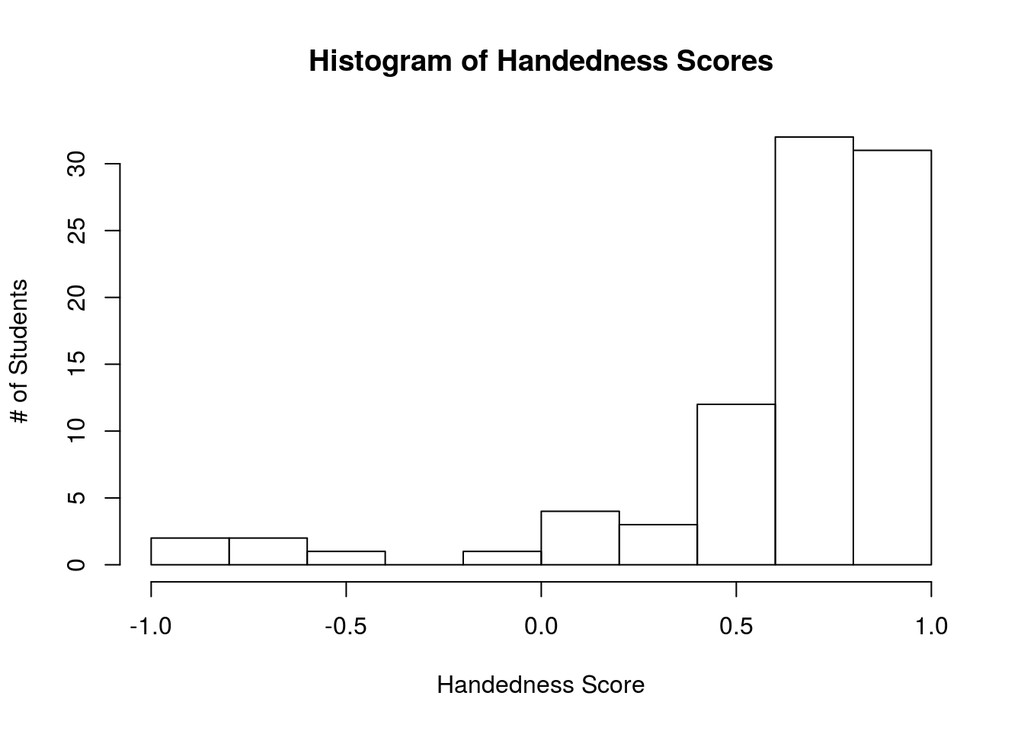

```r
survey[ , hist(handedness, xlab = 'Handedness Score',
               main = 'Histogram of Handedness Scores',
               ylab = '# of Students')]
```

See `?hist` or `?par` for a full list of options available during plotting; see also the exercises for a chance to explore some of these.

Recall that R doesn’t care if you use single or double quotes, as long are you’re consistent (the symbol you start with is the symbol you end with).

You can change the number of bins via the argument `breaks`

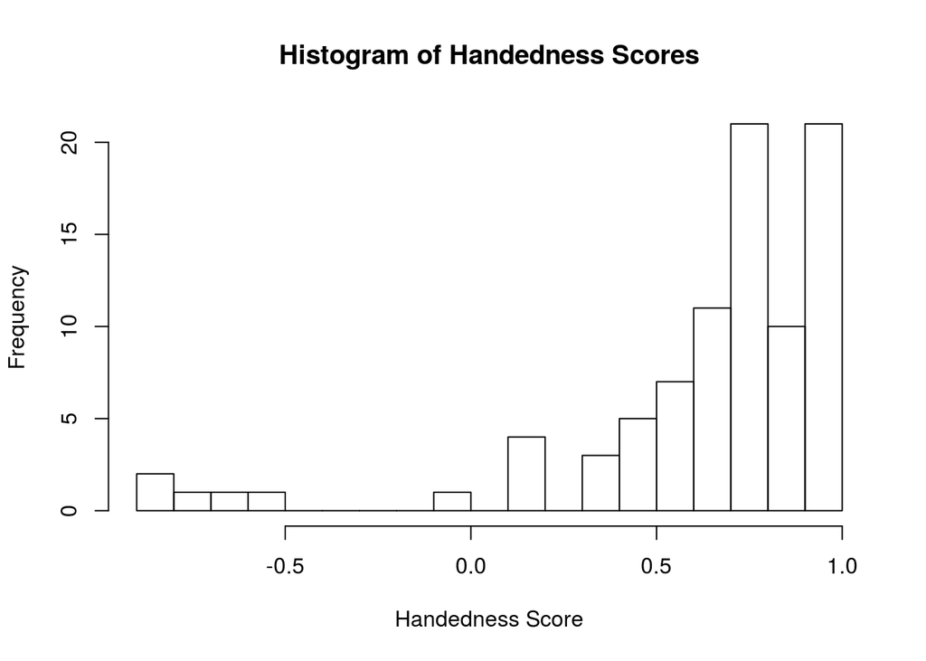

```r
survey[ , hist(handedness, breaks = 20, xlab = 'Handedness Score',
               main = 'Histogram of Handedness Scores')]
```

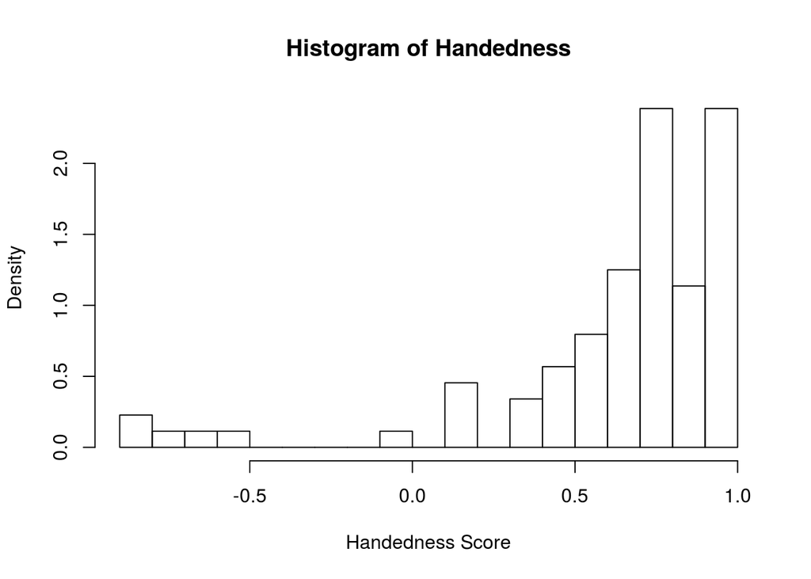

```r
survey[ , hist(handedness, breaks = 20, freq = FALSE,
               xlab = 'Handedness Score', main = 'Histogram of Handedness')]
```

Notice that if you don’t supply a label for the y-axis, R defaults to `"Frequency"` unless you set `freq = FALSE`, in which case it uses `"Density"`. We’ll learn about densities later in the course.

## Scatter/Line Plots: `plot`

The general-purpose command for plotting in R is rather unimaginatively called `plot`. This is an incredibly powerful command, but we’ll mostly use it to make simple scatter plots. To plot `height` on the the x-axis and `handspan` on the y-axis, we use the following command:

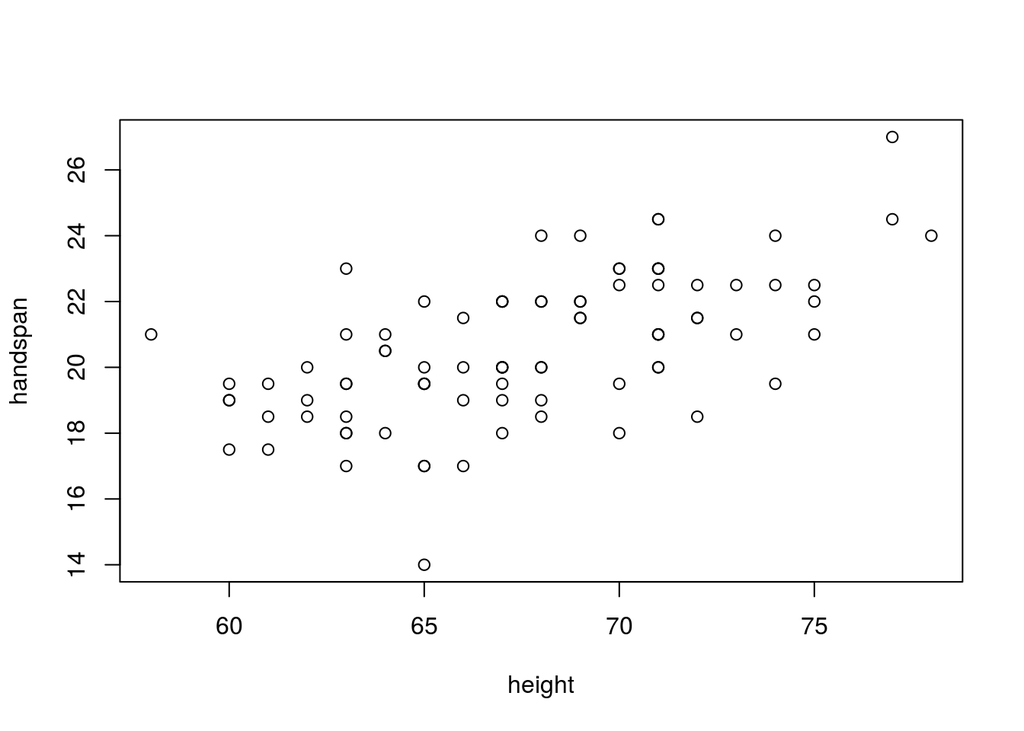

```r
survey[ , plot(height, handspan)]
```

If you change the order, you reverse the plot:

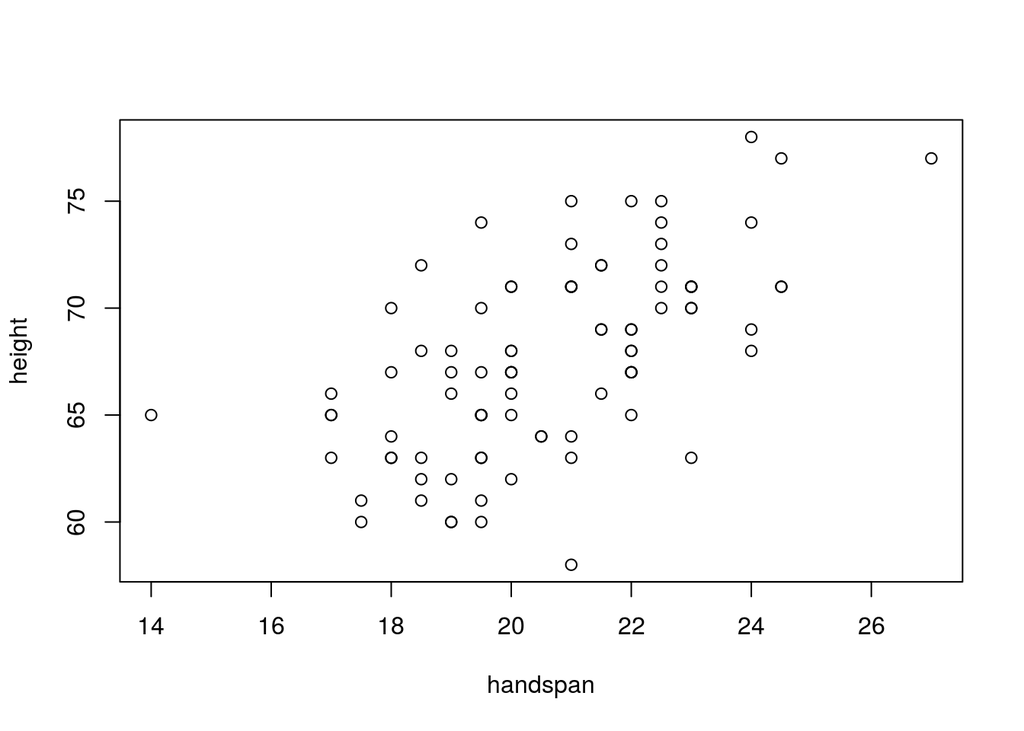

```r
survey[ , plot(handspan, height)]
```

You can use the same arguments for `plot` as you did for `hist` to change the title and axis labels and make the plot look cleaner:

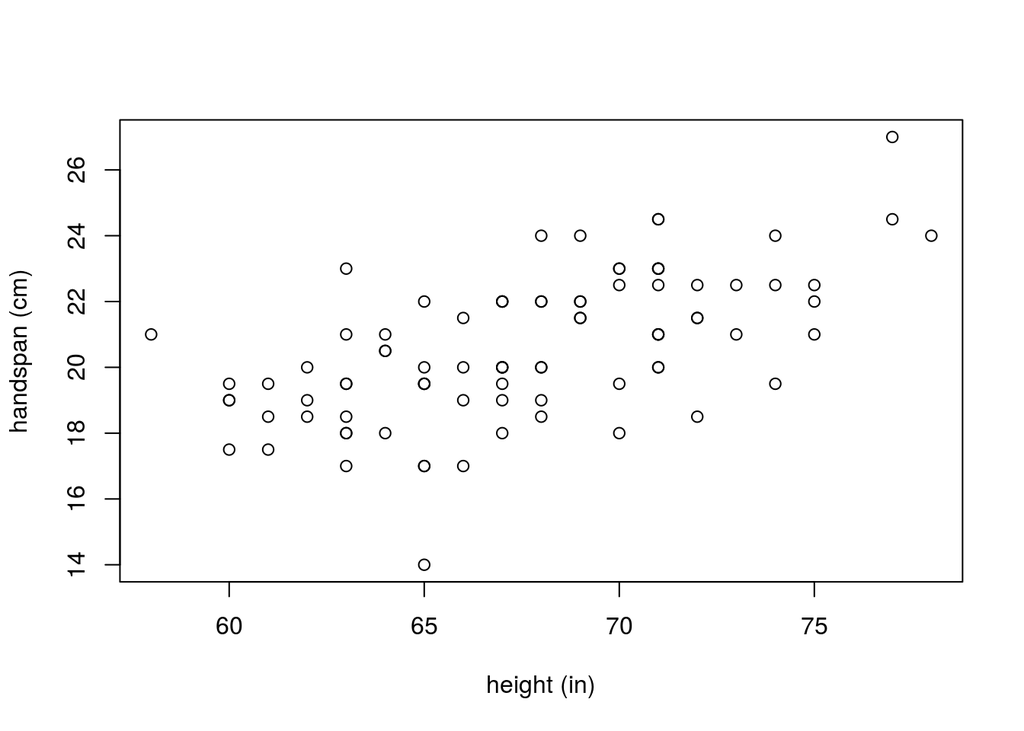

```r
survey[ , plot(height, handspan, xlab = "height (in)", ylab = "handspan (cm)")]
```

Plot has many different arguments (see `?plot`) that you can use to customize the appearance of your plot. We can change the color of the points using the `col` argument:

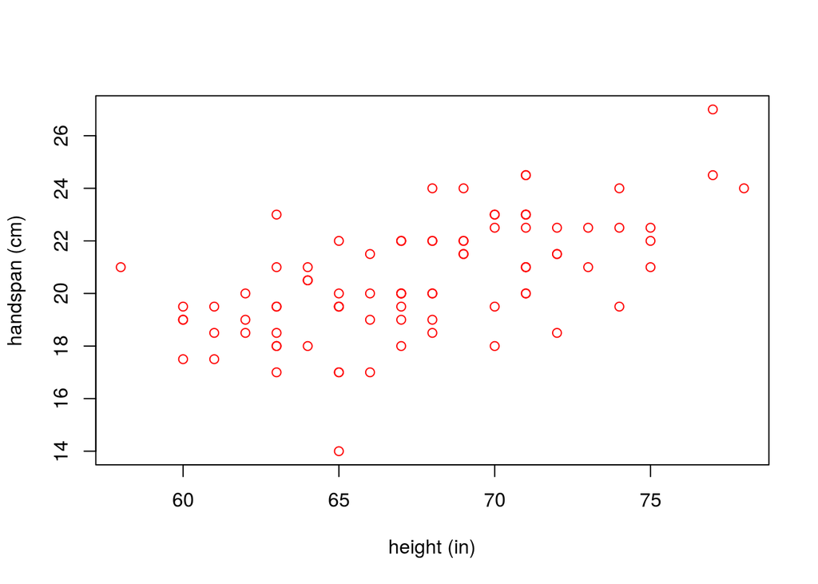

```r
survey[ , plot(height, handspan, xlab = "height (in)",
               ylab = "handspan (cm)", col = "red")]
```

the shape of the points using the `pch` argument:

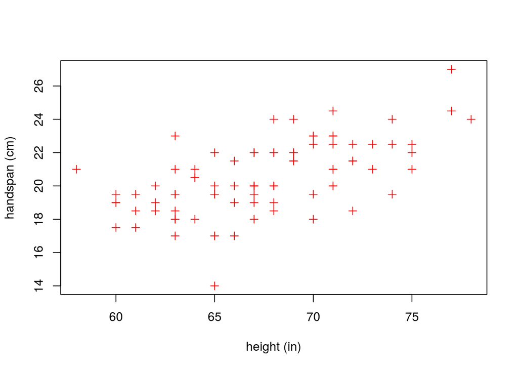

```r
survey[ , plot(height, handspan, xlab = "height (in)",
               ylab = "handspan (cm)", col = "red", pch = 3)]
```

See `?points` for the full list of possible choices for `pch`.

We can even plot connected line segments rather than points using the `type` argument, although this isn’t really useful for the current example:

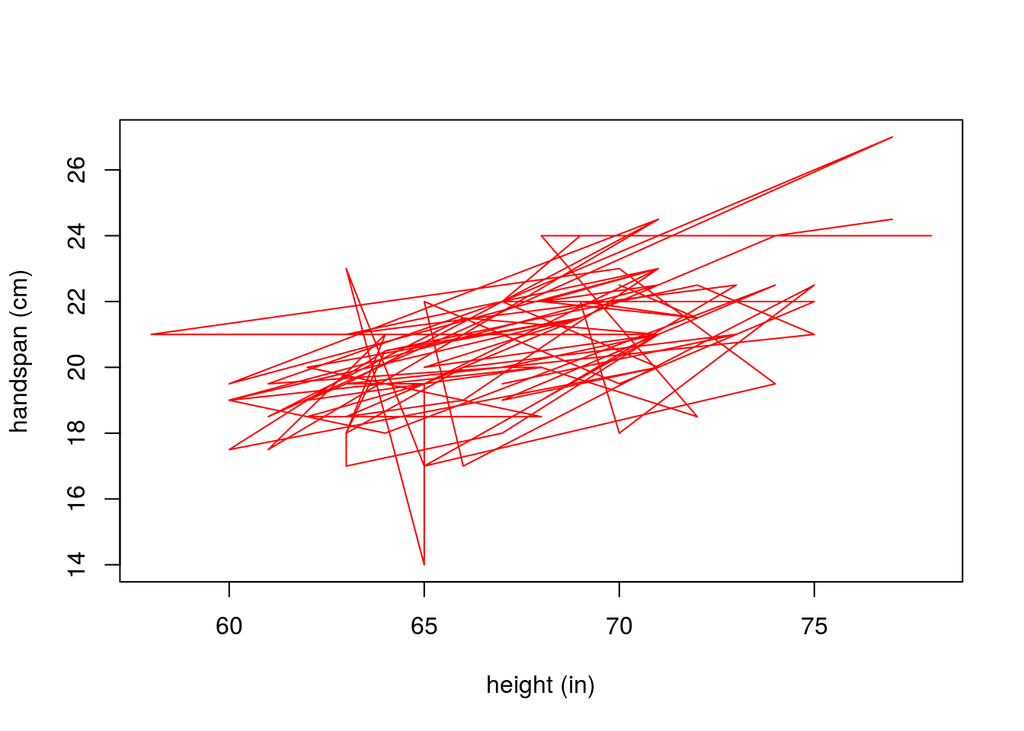

```r
survey[ , plot(height, handspan, xlab = "height (in)",
               ylab = "handspan (cm)", col = "red", pch = 3, type = 'l')]
```

(in `type = 'l'`, `'l'` means _l_ine)

## Scatterplot Matrix: `pairs`

## `pairs`

The function `pairs` is a great way to visualize many columns of a `data.table` at once. Unlike `plot`, whose two first arguments need to be vectors, `pairs` can take a *whole data.table* as its argument. It produces a kind of scatter plot on steroids, in which every column in the dataframe is plotted against *every other column*. Let’s try it out with some of the measurements from the survey:

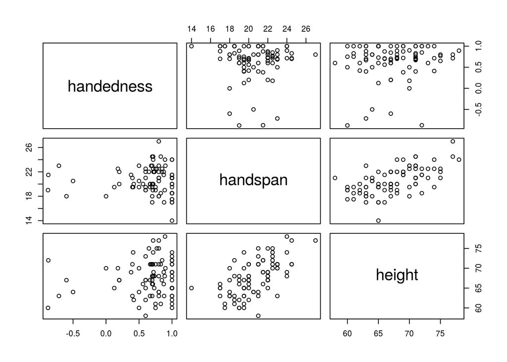

```r
pairs(survey[ , c("handedness", "handspan", "height")])
```

We’re including the three columns `"handedness"`, `"handspan"`, `"height"` since they’re all continuous, as opposed to some of the others.

There seems to be a strong positive relationship between handspan and height but not much of a relationship between handeness and either of the other columns.

It takes a bit of practice to be able to read a `pairs` plot, but the payoff can be huge for concisely understanding the relationships present in a data set. Spend a little time looking at this one to figure it out and look at the help file (`?pairs`) if needed.

## Box Plots: `boxplot`

A boxplot is an alternative way to visualize the distribution of a dataset. The command in R is just what you’d expect, and you can use the same labels as above. The first argument must be a vector:

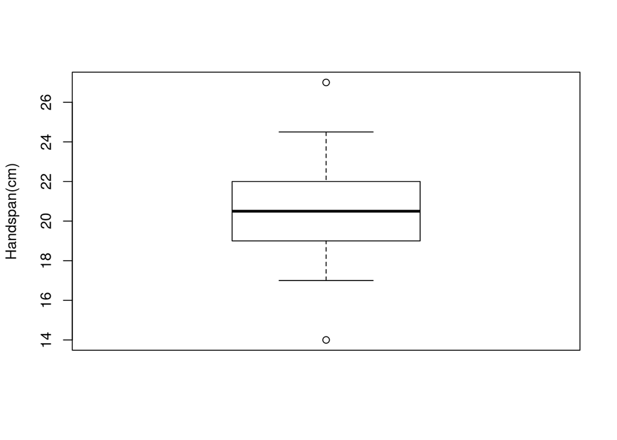

```r
boxplot(survey$handspan, ylab = "Handspan(cm)")
```

The “box” in a box plot shows the middle 50% of the data. The thick line in the middle is the median, and the lines immediately above and below are the 25th and 75th percentiles. This means that the width of the box equals the interquartile range of the data.

Traditionally, the “whiskers” in a boxplot show the maximum and minimum of the data, but R has an interesting special feature. If there are any observations that are extremely unusual (very big or very small compared to all other observations), it leaves them out when deciding where to put the whiskers and just plots them directly. Such points are called “outliers,” like the book by Malcom Gladwell. We see two such outliers in the plot above.

In case you’re interested, R considers an outlier to be any point that is more than 1.5 times the interquartile range away from the box. You don’t have to memorize this rule.

One of the main advantages of boxplots over histograms is that they are simple enough to plot side-by-side. This lets us see how the distribution of a numerical variable is related to a categorical variable. For example, we could see how the distribution of handspan differs for men and women as follows:

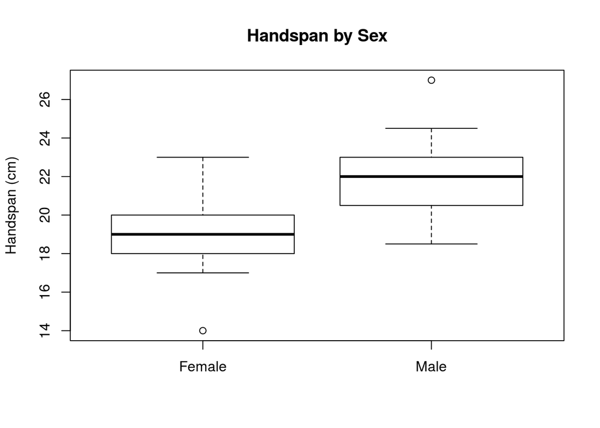

```r
boxplot(handspan ~ sex, data = survey,
        ylab= "Handspan (cm)", main = "Handspan by Sex")
```

The syntax used above is different from what we’ve seen so far but since it will appear again when we look at regression it’s worth spending some time to explain. The syntax `handspan ~ sex` indicates that we want `handspan` *as a function of* `sex`. The argument `data = survey` tells R where to find the variables `handspan` and `sex`: they’re stored as columns in the `data.table` survey.

## One- and Two-way Tables: `table`

The command `table` is used for making cross-tabs, aka two-way tables, a useful way of summarizing the relationship between two categorical variables. Both arguments of `table` must be vectors. For example, we can make a cross-tab of eye color and sex as follows:

```r
survey[ , table(eye.color, sex)]
```

```
##          sex
## eye.color Female Male
##    Black       2    5
##    Blue        4    6
##    Brown      32   26
##    Copper      0    1
##    Green       1    4
##    Hazel       2    2
##    Maroon      0    1
```

You can also use `table` to make a *one-way* crosstab:

```r
survey[ , table(eye.color)]
```

```
## eye.color
##  Black   Blue  Brown Copper  Green  Hazel Maroon
##      7     10     59      1      5      4      1
```

If you want the row/column totals to be printed alongside your table, the approach in R is a little clumsy: you first need to give your table a name and store it, then use the function `addmargins`:

```r
my.table = survey[ , table(eye.color, sex)]
addmargins(my.table)
```

```
##          sex
## eye.color Female Male Sum
##    Black       2    5   7
##    Blue        4    6  10
##    Brown      32   26  58
##    Copper      0    1   1
##    Green       1    4   5
##    Hazel       2    2   4
##    Maroon      0    1   1
##    Sum        41   45  86
```

To convert a cross-tab in R into *percents* rather than counts, we use the function `prop.table`. This is a little clumsy as well. First, store the original table, then pass it as the argument to `prop.table` as you did with `addmargins`

```r
my.table = survey[ , table(eye.color, sex)]
prop.table(my.table)
```

```
##          sex
## eye.color     Female       Male
##    Black  0.02325581 0.05813953
##    Blue   0.04651163 0.06976744
##    Brown  0.37209302 0.30232558
##    Copper 0.00000000 0.01162791
##    Green  0.01162791 0.04651163
##    Hazel  0.02325581 0.02325581
##    Maroon 0.00000000 0.01162791
```

Now you have a table in which percents are expressed as *decimals* (i.e., proportions). For example, the value of 0.37209 in the row `Brown` and the column `Female` indicates that about 37% of the people in the dataset are women who have brown eyes.

To get ordinary percents, we multiply by 100:

```r
100 * prop.table(my.table)
```

```
##          sex
## eye.color    Female      Male
##    Black   2.325581  5.813953
##    Blue    4.651163  6.976744
##    Brown  37.209302 30.232558
##    Copper  0.000000  1.162791
##    Green   1.162791  4.651163
##    Hazel   2.325581  2.325581
##    Maroon  0.000000  1.162791
```

To make this cleaner we can round the result to a desired number of decimal places:

```r
round(100 * prop.table(my.table), digits = 1)
```

```
##          sex
## eye.color Female Male
##    Black     2.3  5.8
##    Blue      4.7  7.0
##    Brown    37.2 30.2
##    Copper    0.0  1.2
##    Green     1.2  4.7
##    Hazel     2.3  2.3
##    Maroon    0.0  1.2
```

```r
round(100 * prop.table(my.table), digits = 0)
```

```
##          sex
## eye.color Female Male
##    Black       2    6
##    Blue        5    7
##    Brown      37   30
##    Copper      0    1
##    Green       1    5
##    Hazel       2    2
##    Maroon      0    1
```

You’ve met several of the summary statistics from class in R Tutorial #1. I’ll remind you of them here and introduce some others.

## `summary`

This command takes a *whole `data.table`* as its argument, unlike the other commands for summary statistics. It gives us the mean of each column along with the five-number summary. It also indicates if there are any missing observations (`NA`’s – more on this below) in the columns:

```r
summary(survey)
```

```
##      sex               credits       eye.color           handedness
##  Length:89          Min.   :4.000   Length:89          Min.   :-0.8800
##  Class :character   1st Qu.:5.000   Class :character   1st Qu.: 0.6000
##  Mode  :character   Median :5.000   Mode  :character   Median : 0.7317
##                     Mean   :5.012                      Mean   : 0.6579
##                     3rd Qu.:5.000                      3rd Qu.: 0.8955
##                     Max.   :6.500                      Max.   : 1.0000
##                     NA's   :3                          NA's   :1
##      height         handspan    height_handspan_ratio
##  Min.   :58.00   Min.   :14.0   Min.   :2.739
##  1st Qu.:64.00   1st Qu.:19.0   1st Qu.:3.091
##  Median :67.00   Median :20.5   Median :3.289
##  Mean   :67.55   Mean   :20.6   Mean   :3.304
##  3rd Qu.:71.00   3rd Qu.:22.0   3rd Qu.:3.455
##  Max.   :78.00   Max.   :27.0   Max.   :4.643
##  NA's   :1       NA's   :1      NA's   :2
```

## Missing Data: `NA`

One ubiquitous fact of real-world data is missingness. For a gallimaufry of reasons, we’re unable to get correct measurements/information about all variables that we observe in all cases.

Being a language for statistics, R handles this missing data with aplomb by handling it under the appelation `NA`. However, any user must understand that trying to perform calculations with missing observations may lead to unexpected outcomes, e.g.:

```r
sum(survey$height)
```

```
## [1] NA
```

Any sum involving a missing observation is missing.

To tell R to ignore missing observations, set the argument `na.rm` to `TRUE`. This will work with pretty much any of the commands you know for performing mathematical operations on a vector:

```r
sum(survey$height, na.rm = TRUE)
```

```
## [1] 5944
```

## Average: `mean`

Calculates the sample mean of a numeric vector

```r
mean(survey$height, na.rm = TRUE)
```

```
## [1] 67.54545
```

Note that *the effective sample size decreases by the number of missing observations*!!

Compare:

```r
#3 observations
mean(1:3)
```

```
## [1] 2
```

```r
#3 observations, but one missing observation --
#  so the denominator in the mean is 2
mean(c(1, 2, NA), na.rm = TRUE)
```

```
## [1] 1.5
```

## Variance: `var`

Calculates the sample variance of a numeric vector

```r
var(survey$height, na.rm = TRUE)
```

```
## [1] 19.74504
```

## Standard Deviation: `sd`

Calculates the sample standard deviation of a numeric vector

```r
sd(survey$height, na.rm = TRUE)
```

```
## [1] 4.443539
```

This is identical to the (positive) square root of the sample variance:

```r
sqrt(var(survey$height, na.rm = TRUE))
```

```
## [1] 4.443539
```

## Median: `median`

Calculates the sample median of a numeric vector

```r
median(survey$height, na.rm = TRUE)
```

```
## [1] 67
```

## Other Quantiles: `quantile`

This function calculates sample quantiles, aka percentiles, of a numeric vector. If you simply pass it a numeric vector with no other arguments, it will give you the five-number summary:

```r
quantile(survey$height, na.rm = TRUE)
```

```
##   0%  25%  50%  75% 100%
##   58   64   67   71   78
```

You can ask for specific quantile by using the argument `probs`

```r
quantile(survey$height, na.rm = TRUE, probs = 0.3)
```

```
## 30%
##  65
```

Note that quantiles are specified as *probabilities* so the preceding command gives the 30th percentile. You can also ask for multiple quantiles at once:

```r
quantile(survey$height, na.rm = TRUE, probs = c(0.1, 0.3, 0.7, 0.9))
```

```
##  10%  30%  70%  90%
## 62.0 65.0 70.0 73.3
```

## Inter-quartile Range: `IQR`

Calculates the interquartile range of a numeric vector (the 75th percentile minus the 25th percentile)

```r
IQR(survey$height, na.rm = TRUE)
```

```
## [1] 7
```

We could also use the `quantile` argument to produce this like so:

```r
x = quantile(survey$height, na.rm = TRUE, probs = c(.25, .75))
x[2] - x[1]
```

```
## 75%
##   7
```

## Extrema: `max`, `min`, `range`, `which.max` and `which.min`

`max` and `min` do exactly what they say:

```r
max(survey$height, na.rm = TRUE)
```

```
## [1] 78
```

```r
min(survey$height, na.rm = TRUE)
```

```
## [1] 58
```

and can be used to calculate the range

```r
max(survey$height, na.rm = TRUE) - min(survey$height, na.rm = TRUE)
```

```
## [1] 20
```

To get both the maximum and minimum at once, you can use the function `range`:

```r
range(survey$height, na.rm = TRUE)
```

```
## [1] 58 78
```

Note that this does *not* compute the *summary statistic* called the range.

Sometimes we’re interested not just in *what* the max is, but *who* obtained the max. For example, we might want to know some other information about who the tallest/shortest person in the survey are. `which.max` and `which.min` return the row number corresponding to the maximum; we can use this to subset the data to display the full row corresponding to the maximum like so:

```r
which.max(survey$height)
```

```
## [1] 67
```

```r
survey[which.max(height)]
```

```
##     sex credits eye.color handedness height handspan height_handspan_ratio
## 1: Male       5     Green      0.894     78       24                  3.25
```

```r
survey[which.min(height)]
```

```
##     sex credits eye.color handedness height handspan height_handspan_ratio
## 1: Male       5     Brown        0.6     58       21              2.761905
```

## Categorical Variables in R: `factor`s

R has a somewhat peculiar way of handling categorical variables. It does so by using what are called `factor` variables. First, an example:

```r
school = c("SAS", "Wharton", "Wharton", "SEAS", "SAS", "Nursing", "SAS")
school_factor = factor(school)
class(school)
```

```
## [1] "character"
```

```r
class(school_factor)
```

```
## [1] "factor"
```

```r
school
```

```
## [1] "SAS"     "Wharton" "Wharton" "SEAS"    "SAS"     "Nursing" "SAS"
```

```r
school_factor
```

```
## [1] SAS     Wharton Wharton SEAS    SAS     Nursing SAS
## Levels: Nursing SAS SEAS Wharton
```

Note that when we pass the `school` `character` vector through the `factor` function, the output, which I’ve called `school_factor`, is now a `"factor"`. Note the subtle difference in how `school` and `school_factor` are printed; the `factor` is most easily distinguished by the extra line starting with `Levels:` directly below the vector itself.

What’s going on here? First, another thing to observe, the `dput` output of `school_factor`. `dput` is an excellent tool to have in your repertoire for dealing with more complicated/unknown objects in R. It simply prints out the most fundamental representation of the object that’s possible; for the things we’ve seen so far, this would not be very illuminating (although you should try looking at the `dput` output of a `data.table` on your own). What happens when we `dput` a `factor`?

```r
dput(school_factor)
```

```
## structure(c(2L, 4L, 4L, 3L, 2L, 1L, 2L), .Label = c("Nursing",
## "SAS", "SEAS", "Wharton"), class = "factor")
```

Recall that `school` has 7 elements. The core of what we see here is that underneath the hood, the thing that has 7 elements in `school_factor` is now a vector of *integers*: `c(2L, 4L, 4L, 3L, 2L, 1L, 2L)`.

A `factor` in R is a *labelled integer vector*. The “labels” are actually called “levels”, as we can see from the `levels` function:

```r
levels(school_factor)
```

```
## [1] "Nursing" "SAS"     "SEAS"    "Wharton"
```

Note that the levels are in alphabetical order. The integer vector tells which label corresponds to a given element – for example, the first `2L` corresponds to `"SAS"`, which is the second element of `school_factor`’s levels – `levels(school_factor)[2]`.

There are some historical reasons why categorical variables are handled like this; interested souls can read more [here](http://simplystatistics.org/2015/07/24/stringsasfactors-an-unauthorized-biography/). Most of the time, you’ll be well-served just to keep variables as `character` instead of `factor`; the primary limitation is that categorical variables stored as `character` *must* have their levels in alphabetical order, whereas there are ways to re-order the levels of a `factor` variable to be in whatever order you’d like, which is often very helpful in regression settings.

Note that `eye.color` is currently stored as a `character` variable. How can we convert it to a `factor`? We have to use `:=` again:

```r
summary(survey$eye.color)
```

```
##    Length     Class      Mode
##        89 character character
```

```r
survey[ , eye.color := factor(eye.color)]
summary(survey$eye.color)
```

```
##  Black   Blue  Brown Copper  Green  Hazel Maroon   NA's
##      7     10     59      1      5      4      1      2
```

Note what’s happening in the `:=` assignment line – we’re overwriting `eye.color` with a `factor` version of itself.

## Averages by Category: `by`

Often, we want to calculate summary statistics for a `data.table` broken down by the values of a categorical variable. `data.table` has a very simple way to perform such group-wise summaries – the `by` argument inside `[]`; let’s see some examples.

First we’ll use it to compare the average height of men in the class to that of women:

```r
survey[ , mean(height, na.rm = TRUE), by = sex]
```

```
##       sex       V1
## 1:   Male 70.37778
## 2: Female 64.50000
## 3:     NA 68.00000
```

If we wanted to compare the variance of height by sex, we would just change `mean` to `var`

```r
survey[ , var(height, na.rm = TRUE), by = sex]
```

```
##       sex        V1
## 1:   Male 14.240404
## 2: Female  8.304878
## 3:     NA        NA
```

Note that the name of the outcome variable was automatically chosen as `V1` in both cases, which might make it hard to distinguish. If we want the name to be more meaningful, we use the following syntax:

```r
survey[ , .(variance = var(height, na.rm = TRUE)), by = sex]
```

```
##       sex  variance
## 1:   Male 14.240404
## 2: Female  8.304878
## 3:     NA        NA
```

We 1) wrap the computation in the `j` argument with `.()` and 2) assign the computation in `j` to a name, here `var(height, na.rm = TRUE)` is being assigned to the name `variance`.

Now, suppose we wanted to compare average height by *eye color*. To do this, simply change the `by` variable to `eye.color`:

```r
survey[ , mean(height, na.rm = TRUE), by = eye.color]
```

```
##    eye.color       V1
## 1:     Brown 66.77966
## 2:      Blue 69.00000
## 3:     Black 68.71429
## 4:     Hazel 67.75000
## 5:     Green 71.50000
## 6:        NA 64.00000
## 7:    Maroon 74.00000
## 8:    Copper 74.00000
```

It’s not much harder to find summaries grouped by two or more variables. Suppose we wanted to calculate average height by sex *and* credits. We simply surround the argument to `by` with `.()`, just like above when we wanted to name the output:

```r
survey[ , .(avg_height = mean(height, na.rm = TRUE)), by = .(sex, credits)]
```

```
##        sex credits avg_height
##  1:   Male     5.0   70.00000
##  2: Female     5.0   64.79167
##  3: Female      NA   64.66667
##  4: Female     4.0   65.00000
##  5: Female     6.0   63.33333
##  6:   Male     4.0   71.11111
##  7:   Male     5.5   69.60000
##  8: Female     6.5   65.00000
##  9:   Male     6.0   71.00000
## 10:   Male     4.5   72.00000
## 11:     NA     5.5   68.00000
```

This contains all the information we want, but it’s not displayed in a particularly convenient format. Firstly, we may like to ignore the students with `sex` or `credits` missing like so using the function `is.na` and the logical operators `&` and `!`:

The function `is.na` performed on a vector returns whether each element is missing or not:

```r
x = c(1, 2, NA, 3, NA, 4)
is.na(x)
```

```
## [1] FALSE FALSE  TRUE FALSE  TRUE FALSE
```

`!` is the negation operator – it turns `TRUE` to `FALSE` and vice-versa:

```r
!is.na(x)
```

```
## [1]  TRUE  TRUE FALSE  TRUE FALSE  TRUE
```

`&` is the element-wise compound operator – `logical1 & logical2` is `TRUE` only on those elements for which *both* `logical1` *and* `logical2` are `TRUE`:

```r
y = c(NA, 1, NA, 2, 3, NA)
is.na(y)
```

```
## [1]  TRUE FALSE  TRUE FALSE FALSE  TRUE
```

```r
!is.na(y)
```

```
## [1] FALSE  TRUE FALSE  TRUE  TRUE FALSE
```

```r
!is.na(x) & !is.na(y)
```

```
## [1] FALSE  TRUE FALSE  TRUE FALSE FALSE
```

So to exclude observations for which `sex` or `credits` are missing can be accomplished like so:

```r
survey[!is.na(sex) & !is.na(credits),
       .(avg_height = mean(height, na.rm = TRUE)),
       by = .(sex, credits)]
```

```
##       sex credits avg_height
## 1:   Male     5.0   70.00000
## 2: Female     5.0   64.79167
## 3: Female     4.0   65.00000
## 4: Female     6.0   63.33333
## 5:   Male     4.0   71.11111
## 6:   Male     5.5   69.60000
## 7: Female     6.5   65.00000
## 8:   Male     6.0   71.00000
## 9:   Male     4.5   72.00000
```

Lastly, it would be nice to have the results in better order; to do this, we use the argument `keyby` instead of `by`. `keyby` is exactly the same as `by`, except that it sorts the output:

```r
survey[!is.na(sex) & !is.na(credits),
       .(avg_height = mean(height, na.rm = TRUE)),
       keyby = .(sex, credits)]
```

```
##       sex credits avg_height
## 1: Female     4.0   65.00000
## 2: Female     5.0   64.79167
## 3: Female     6.0   63.33333
## 4: Female     6.5   65.00000
## 5:   Male     4.0   71.11111
## 6:   Male     4.5   72.00000
## 7:   Male     5.0   70.00000
## 8:   Male     5.5   69.60000
## 9:   Male     6.0   71.00000
```

## `cut`

In class we talked about the idea of putting numerical data into “bins” to make a histogram. More generally, it’s sometimes necessary to convert numerical data into categorical data. A classic example is converting scores from a course into letter grades. You can do this using the command `cut`. (In fact, this is the function I’ll use to determine your grades at the end of the semester!) First I’ll create some fake grade data for us to play with:

```r
grades = c(67, 93, 85, 82, 88, 86, 78, 97, 74, 77, 81)
```

The `cut` function is a little tricky, so it’s worth opening the help file (`?cut`) to consult as you read this. Its first argument is a numeric vector: the vector we want to “cut”. It’s second argument gives the “cut points.” Let’s try this out with some simple grade boundaries:

```r
cut(grades, c(60, 70, 80, 90, 100))
```

```
##  [1] (60,70]  (90,100] (80,90]  (80,90]  (80,90]  (80,90]  (70,80]
##  [8] (90,100] (70,80]  (70,80]  (80,90]
## Levels: (60,70] (70,80] (80,90] (90,100]
```

`cut` has created a `factor`, which we can tell because of the line `"Levels: (60,70] ..."` that appears in the output. Notice that by default the intervals used in cut are “open on the left, closed on the right.” You can reverse this by setting `right = FALSE`

```r
cut(grades, c(60, 70, 80, 90, 100), right = FALSE)
```

```
##  [1] [60,70)  [90,100) [80,90)  [80,90)  [80,90)  [80,90)  [70,80)
##  [8] [90,100) [70,80)  [70,80)  [80,90)
## Levels: [60,70) [70,80) [80,90) [90,100)
```

This is what we’d use for grade cut-offs since they take the form “X or higher.”

The last step is to add an additional argument to `cut` that gives the factor levels meangingful names: in this case, letter grades:

```r
cut(grades, c(60, 70, 80, 90, 100),
    labels = c("D", "C", "B", "A"), right = FALSE)
```

```
##  [1] D A B B B B C A C C B
## Levels: D C B A
```

Notice that if you used $n$ breakpoints, you need $n-1$ labels since they correspond to the “gaps” between the breaks.

# Exploring the Titanic

Now it’s your turn: using what you’ve learned above, you’ll take a closer look at the titanic dataset introduced in R Tutorial #1. You already know enough R to answer some interesting questions, so let’s dive in!

#### A Helpful Hint: Taking the mean of a vector of ones and zeros is the *same thing* as calculating the *proportion of ones*.

1. Read the documentation file for the titanic dataset so that you know what each column in the data represents: http://www.ditraglia.com/econ103/titanic3.txt
2. Download the data, store it in a `data.table` called `titanic`, and display the first few rows.

The URL where the data is stored is:

http://www.ditraglia.com/econ103/titanic3.csv

3. We’ll only be using the following columns of titanic for this example: `pclass`, `survived`, `sex`, `age`, and `fare`. Delete the other columns from the data set. (Note that I did the same thing above with the `survey` data.) Display the first few rows to make sure your command worked.
4. Convert the variables `sex` and `pclass` to `factor`.
5. Using the command `summary` to get an overview of the dataset, answer the following questions:
- Are there any missing values in this dataset?
- What was the average age of passengers on the Titanic?
- What was the average ticket price for passengers on the ship?
- Do the ticket prices show evidence of skewness? If so, are they positively or negatively skewed?
- Were there more men or women aboard the Titanic?
- What proportion of the passengers survived the disaster?
- To which social class did most of the passengers belong?
6. Being sure to allow for missing values if necessary, calculate (or plot) and interpret the following:
- The standard deviation of fares
- The 90th Percentile of fares
- Histogram of fares, colored red
7. Create a boxplot of `fare` by `pclass` and interpret your results.
- Explore using the `horizontal` and `las` arguments. See `?boxplot` and `?par`.
8. Answer the following related to those passengers who survived the disaster:
- What was the average age of the survivors?
- Among the survivors, were there more men or women?
- Do you notice anything different about social class for survivors compared to all passengers?
9. Who paid more, on average, for passage on the titanic: men or women?
10. Create a table of mean fares broken down by `sex` and `pclass`. How does this relate to your answer to the preceding question?
11. How did the fraction of survivors vary by `sex` `pclass`? Can you think of a possible explanation for the pattern you see in the data?
12. Add to `titanic` a categorical variable called `age.group` from the numerical variable `age` using the following cutoffs (http://www.statcan.gc.ca/concepts/definitions/age2-eng.htm):
- Child = [0, 15)
- Youth = [15, 25)
- Adult = [25, 65)
- Senior = [65, 200)
13. Create two tables: one for men and one for women. Each table should break down survival proportions by `pclass` and `age.group`. [Hint: `by = .()` can accept more than two arguments] What do your results suggest? Is there any thing wrong with the way we defined the `"Senior"` age group in the previous part?